# Week 7 Data Assignment

Vanessa Kellermann

2026-04-25

## Instructions

- Answer all questions in the sections below.
- Keep written responses concise (max 100 words where indicated).
- Ensure your code runs without errors.
- Knit this document before submission.

## Setup

```r
#start off with a clear working environment
rm(list =ls())

# Load dataset (make sure the file is in your working directory)
data <- read.csv("dataset_1.csv")

# Inspect the data
head(data)
```

```
##   Population Treatment KnockdownTime
## 1      Urban     LowCu      58.22691
## 2      Urban     LowCu      60.07978
## 3      Urban     LowCu      55.45034
## 4      Urban     LowCu      55.91204
## 5      Urban     LowCu      63.53547
## 6      Urban     LowCu      57.19755
```

```r
str(data)
```

```
## 'data.frame':    120 obs. of  3 variables:
##  $ Population   : chr  "Urban" "Urban" "Urban" "Urban" ...
##  $ Treatment    : chr  "LowCu" "LowCu" "LowCu" "LowCu" ...
##  $ KnockdownTime: num  58.2 60.1 55.5 55.9 63.5 ...
```

```r
# Convert variables to factors if needed
data$Population <- as.factor(data$Population)
data$Treatment <- as.factor(data$Treatment)
```

#Answer in bullet points:

Part 2: Hypothesis (5 marks)

(Max 100 words)

Write a clear, testable, and directional hypothesis. Make sure you include both variables and provide a brief biological justification.

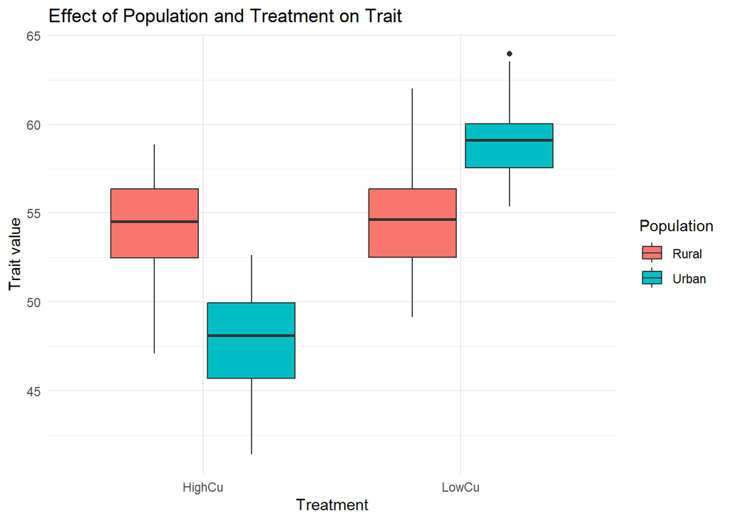

```r
library(ggplot2)

ggplot(data, aes(x = Treatment,y = KnockdownTime, fill = Population)) +
  geom_boxplot() +
  labs(
    x = "Treatment",
    y = "Trait value",
    title = "Effect of Population and Treatment on Trait"
  ) +
  theme_minimal()
```

```r
####Try plotting the data with Population on the x and fill = Treatment
```

Question: Which is the best way to plot the data for the question you are interested in, comparing populations next to each other or treatments next to each other? Explain why, hint think about your hypothesis

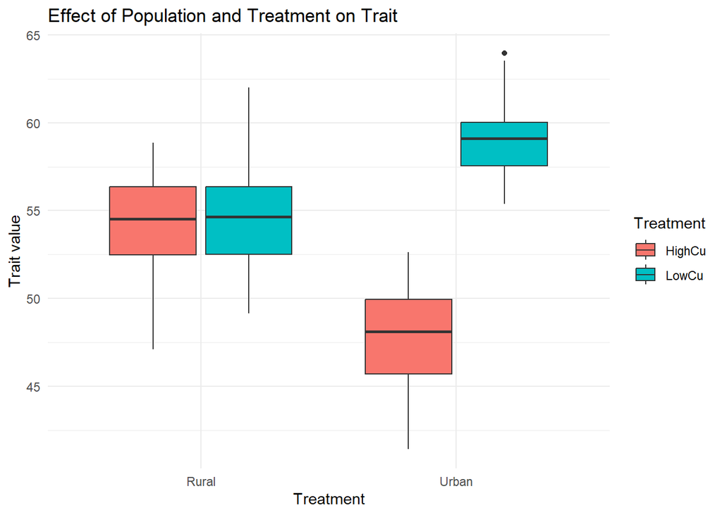

```r
#Here are three different plot types, plot data and then decide which shows the patterns clearest

#boxplot
ggplot(data, aes(x = Population, y = KnockdownTime, fill = Treatment)) +
  geom_boxplot() +
  labs(
    x = "Treatment",
    y = "Trait value",
    title = "Effect of Population and Treatment on Trait"
  ) +
  theme_minimal()
```

```r
# Mean point plot (with error bars)
library(dplyr)
summary_data <- data %>%
  group_by(Population, Treatment) %>%
  summarise(
    mean_KnockdownTime = mean(KnockdownTime, na.rm = TRUE),
    se_KnockdownTime = sd(KnockdownTime, na.rm = TRUE) / sqrt(n())
  )
summary_data
```

```
## # A tibble: 4 × 4
## # Groups:   Population [2]
##   Population Treatment mean_KnockdownTime se_KnockdownTime
##   <fct>      <fct>                  <dbl>            <dbl>
## 1 Rural      HighCu                  54.2            0.539
## 2 Rural      LowCu                   54.7            0.571
## 3 Urban      HighCu                  47.8            0.503
## 4 Urban      LowCu                   59.0            0.398
```

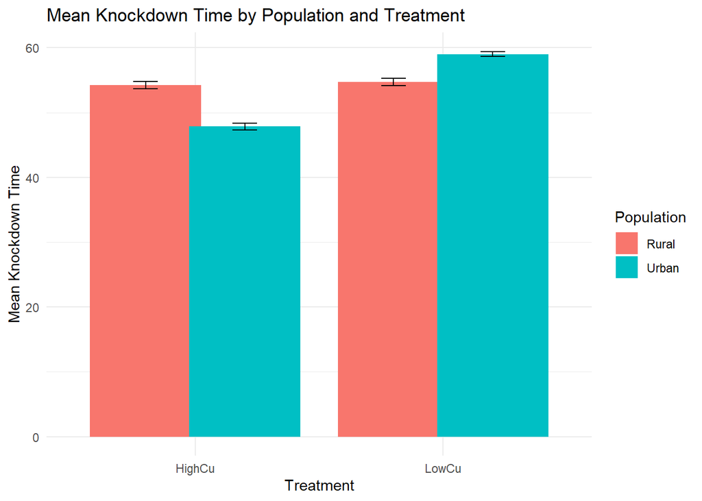

```r
#Ignore warning

#Bar graph

ggplot(summary_data, aes(x = Treatment, y = mean_KnockdownTime, fill = Population)) +
  geom_col(position = position_dodge(width = 0.8)) +
  geom_errorbar(aes(ymin = mean_KnockdownTime - se_KnockdownTime,
                    ymax = mean_KnockdownTime + se_KnockdownTime),
                position = position_dodge(width = 0.8),
                width = 0.2) +
  labs(x = "Treatment",
       y = "Mean Knockdown Time",
       title = "Mean Knockdown Time by Population and Treatment") +
  theme_minimal()
```

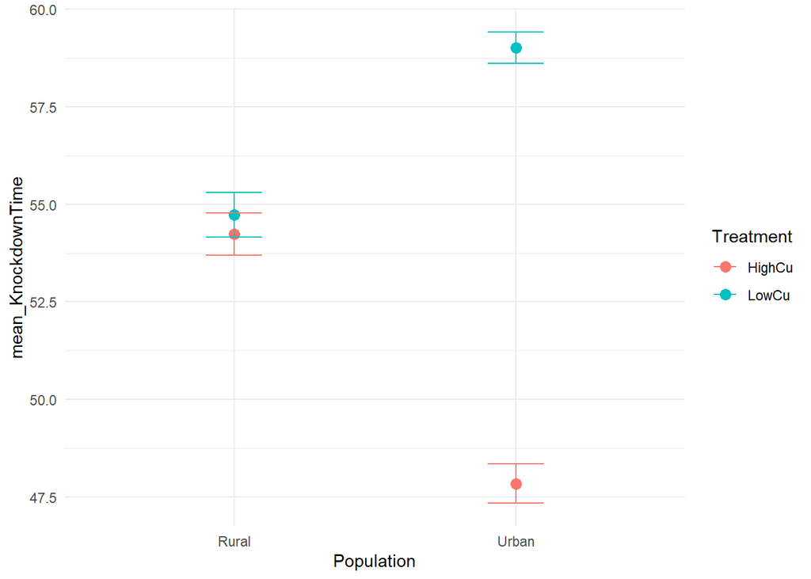

```r
# Dot plot with means and standard errors

ggplot(summary_data, aes(x = Population, y = mean_KnockdownTime, color = Treatment)) +
  geom_point(size = 3) +  # Plot mean values
  geom_errorbar(aes(ymin = mean_KnockdownTime - se_KnockdownTime, ymax = mean_KnockdownTime + se_KnockdownTime), width = 0.2) +
    theme_minimal()
```

```r
#Once you have plotted all three types run the code one final time using the plot
#type you think best describes the data
```

Part 4:

Write a figure caption

(Max 100 words)

Describe the pattern shown in your figure State whether it supports your hypothesis Provide a brief biological explanation

##Double check: All sections completed Code runs without errors Figure is clear and labelled Responses are within word limits Document successfully knitted